# Assignment 01 - Exploratory Data Analysis

Juehan Wang

9/15/2021

# Primary question:

Whether daily concentrations of PM2.5 have decreased in California over the last 15 years (from 2004 to 2019).

## Step 1

### Read the data

```r
ad_2004 <- data.table::fread("/Users/juehanwang/Desktop/566/Assignments/Data/ad_viz_plotval_data.csv")
ad_2019 <- data.table::fread("/Users/juehanwang/Desktop/566/Assignments/Data/ad_viz_plotval_data (1).csv")
```

### Check the dimensions, headers, footers, variable names and variable types.

```r
dim(ad_2004)
```

```
## [1] 19233    20
```

```r
head(ad_2004)
```

```
##          Date Source  Site ID POC Daily Mean PM2.5 Concentration    UNITS
## 1: 01/01/2004    AQS 60010007   1                            8.9 ug/m3 LC
## 2: 01/02/2004    AQS 60010007   1                           12.2 ug/m3 LC
## 3: 01/03/2004    AQS 60010007   1                           16.5 ug/m3 LC
## 4: 01/04/2004    AQS 60010007   1                           18.1 ug/m3 LC
## 5: 01/05/2004    AQS 60010007   1                           11.5 ug/m3 LC
## 6: 01/06/2004    AQS 60010007   1                           32.5 ug/m3 LC
##    DAILY_AQI_VALUE Site Name DAILY_OBS_COUNT PERCENT_COMPLETE
## 1:              37 Livermore               1              100
## 2:              51 Livermore               1              100
## 3:              60 Livermore               1              100
## 4:              64 Livermore               1              100
## 5:              48 Livermore               1              100
## 6:              94 Livermore               1              100
##    AQS_PARAMETER_CODE                     AQS_PARAMETER_DESC CBSA_CODE
```

[output cut: 20 more lines]

```r
tail(ad_2004)
```

```
##          Date Source  Site ID POC Daily Mean PM2.5 Concentration    UNITS
## 1: 12/14/2004    AQS 61131003   1                             11 ug/m3 LC
## 2: 12/17/2004    AQS 61131003   1                             16 ug/m3 LC
## 3: 12/20/2004    AQS 61131003   1                             17 ug/m3 LC
## 4: 12/23/2004    AQS 61131003   1                              9 ug/m3 LC
## 5: 12/26/2004    AQS 61131003   1                             24 ug/m3 LC
## 6: 12/29/2004    AQS 61131003   1                              9 ug/m3 LC
##    DAILY_AQI_VALUE            Site Name DAILY_OBS_COUNT PERCENT_COMPLETE
## 1:              46 Woodland-Gibson Road               1              100
## 2:              59 Woodland-Gibson Road               1              100
## 3:              61 Woodland-Gibson Road               1              100
## 4:              38 Woodland-Gibson Road               1              100
## 5:              76 Woodland-Gibson Road               1              100
## 6:              38 Woodland-Gibson Road               1              100
##    AQS_PARAMETER_CODE       AQS_PARAMETER_DESC CBSA_CODE
```

[output cut: 20 more lines]

```r
str(ad_2004)
```

```
## Classes 'data.table' and 'data.frame':   19233 obs. of  20 variables:
##  $ Date                          : chr  "01/01/2004" "01/02/2004" "01/03/2004" "01/04/2004" ...
##  $ Source                        : chr  "AQS" "AQS" "AQS" "AQS" ...
##  $ Site ID                       : int  60010007 60010007 60010007 60010007 60010007 60010007 60010007 60010007 60010007 60010007 ...
##  $ POC                           : int  1 1 1 1 1 1 1 1 1 1 ...
##  $ Daily Mean PM2.5 Concentration: num  8.9 12.2 16.5 18.1 11.5 32.5 14 29.9 21 15.7 ...
##  $ UNITS                         : chr  "ug/m3 LC" "ug/m3 LC" "ug/m3 LC" "ug/m3 LC" ...
##  $ DAILY_AQI_VALUE               : int  37 51 60 64 48 94 55 88 70 59 ...
##  $ Site Name                     : chr  "Livermore" "Livermore" "Livermore" "Livermore" ...
##  $ DAILY_OBS_COUNT               : int  1 1 1 1 1 1 1 1 1 1 ...
##  $ PERCENT_COMPLETE              : num  100 100 100 100 100 100 100 100 100 100 ...
##  $ AQS_PARAMETER_CODE            : int  88101 88502 88502 88101 88502 88502 88101 88502 88502 88101 ...
##  $ AQS_PARAMETER_DESC            : chr  "PM2.5 - Local Conditions" "Acceptable PM2.5 AQI & Speciation Mass" "Acceptable PM2.5 AQI & Speciation Mass" "PM2.5 - Local Conditions" ...
##  $ CBSA_CODE                     : int  41860 41860 41860 41860 41860 41860 41860 41860 41860 41860 ...
##  $ CBSA_NAME                     : chr  "San Francisco-Oakland-Hayward, CA" "San Francisco-Oakland-Hayward, CA" "San Francisco-Oakland-Hayward, CA" "San Francisco-Oakland-Hayward, CA" ...
##  $ STATE_CODE                    : int  6 6 6 6 6 6 6 6 6 6 ...
##  $ STATE                         : chr  "California" "California" "California" "California" ...
##  $ COUNTY_CODE                   : int  1 1 1 1 1 1 1 1 1 1 ...
##  $ COUNTY                        : chr  "Alameda" "Alameda" "Alameda" "Alameda" ...
##  $ SITE_LATITUDE                 : num  37.7 37.7 37.7 37.7 37.7 ...
##  $ SITE_LONGITUDE                : num  -122 -122 -122 -122 -122 ...
##  - attr(*, ".internal.selfref")=<externalptr>
```

```r
dim(ad_2019)
```

```
## [1] 53086    20
```

```r
head(ad_2019)
```

```
##          Date Source  Site ID POC Daily Mean PM2.5 Concentration    UNITS
## 1: 01/01/2019    AQS 60010007   3                            5.7 ug/m3 LC
## 2: 01/02/2019    AQS 60010007   3                           11.9 ug/m3 LC
## 3: 01/03/2019    AQS 60010007   3                           20.1 ug/m3 LC
## 4: 01/04/2019    AQS 60010007   3                           28.8 ug/m3 LC
## 5: 01/05/2019    AQS 60010007   3                           11.2 ug/m3 LC
## 6: 01/06/2019    AQS 60010007   3                            2.7 ug/m3 LC
##    DAILY_AQI_VALUE Site Name DAILY_OBS_COUNT PERCENT_COMPLETE
## 1:              24 Livermore               1              100
## 2:              50 Livermore               1              100
## 3:              68 Livermore               1              100
## 4:              86 Livermore               1              100
## 5:              47 Livermore               1              100
## 6:              11 Livermore               1              100
##    AQS_PARAMETER_CODE       AQS_PARAMETER_DESC CBSA_CODE
```

[output cut: 20 more lines]

```r
tail(ad_2019)
```

```
##          Date Source  Site ID POC Daily Mean PM2.5 Concentration    UNITS
## 1: 11/11/2019    AQS 61131003   1                           13.5 ug/m3 LC
## 2: 11/17/2019    AQS 61131003   1                           18.1 ug/m3 LC
## 3: 11/29/2019    AQS 61131003   1                           12.5 ug/m3 LC
## 4: 12/17/2019    AQS 61131003   1                           23.8 ug/m3 LC
## 5: 12/23/2019    AQS 61131003   1                            1.0 ug/m3 LC
## 6: 12/29/2019    AQS 61131003   1                            9.1 ug/m3 LC
##    DAILY_AQI_VALUE            Site Name DAILY_OBS_COUNT PERCENT_COMPLETE
## 1:              54 Woodland-Gibson Road               1              100
## 2:              64 Woodland-Gibson Road               1              100
## 3:              52 Woodland-Gibson Road               1              100
## 4:              76 Woodland-Gibson Road               1              100
## 5:               4 Woodland-Gibson Road               1              100
## 6:              38 Woodland-Gibson Road               1              100
##    AQS_PARAMETER_CODE       AQS_PARAMETER_DESC CBSA_CODE
```

[output cut: 20 more lines]

```r
str(ad_2019)
```

```
## Classes 'data.table' and 'data.frame':   53086 obs. of  20 variables:
##  $ Date                          : chr  "01/01/2019" "01/02/2019" "01/03/2019" "01/04/2019" ...
##  $ Source                        : chr  "AQS" "AQS" "AQS" "AQS" ...
##  $ Site ID                       : int  60010007 60010007 60010007 60010007 60010007 60010007 60010007 60010007 60010007 60010007 ...
##  $ POC                           : int  3 3 3 3 3 3 3 3 3 3 ...
##  $ Daily Mean PM2.5 Concentration: num  5.7 11.9 20.1 28.8 11.2 2.7 2.8 7 3.1 7.1 ...
##  $ UNITS                         : chr  "ug/m3 LC" "ug/m3 LC" "ug/m3 LC" "ug/m3 LC" ...
##  $ DAILY_AQI_VALUE               : int  24 50 68 86 47 11 12 29 13 30 ...
##  $ Site Name                     : chr  "Livermore" "Livermore" "Livermore" "Livermore" ...
##  $ DAILY_OBS_COUNT               : int  1 1 1 1 1 1 1 1 1 1 ...
##  $ PERCENT_COMPLETE              : num  100 100 100 100 100 100 100 100 100 100 ...
##  $ AQS_PARAMETER_CODE            : int  88101 88101 88101 88101 88101 88101 88101 88101 88101 88101 ...
##  $ AQS_PARAMETER_DESC            : chr  "PM2.5 - Local Conditions" "PM2.5 - Local Conditions" "PM2.5 - Local Conditions" "PM2.5 - Local Conditions" ...
##  $ CBSA_CODE                     : int  41860 41860 41860 41860 41860 41860 41860 41860 41860 41860 ...
##  $ CBSA_NAME                     : chr  "San Francisco-Oakland-Hayward, CA" "San Francisco-Oakland-Hayward, CA" "San Francisco-Oakland-Hayward, CA" "San Francisco-Oakland-Hayward, CA" ...
##  $ STATE_CODE                    : int  6 6 6 6 6 6 6 6 6 6 ...
##  $ STATE                         : chr  "California" "California" "California" "California" ...
##  $ COUNTY_CODE                   : int  1 1 1 1 1 1 1 1 1 1 ...
##  $ COUNTY                        : chr  "Alameda" "Alameda" "Alameda" "Alameda" ...
##  $ SITE_LATITUDE                 : num  37.7 37.7 37.7 37.7 37.7 ...
##  $ SITE_LONGITUDE                : num  -122 -122 -122 -122 -122 ...
##  - attr(*, ".internal.selfref")=<externalptr>
```

### Take a closer look at the key variables.

```r
table(ad_2004$Date)
```

```
##
## 01/01/2004 01/02/2004 01/03/2004 01/04/2004 01/05/2004 01/06/2004 01/07/2004
##         80         23         22        108         19         22         89
## 01/08/2004 01/09/2004 01/10/2004 01/11/2004 01/12/2004 01/13/2004 01/14/2004
##         26         25        128         25         24         96         23
## 01/15/2004 01/16/2004 01/17/2004 01/18/2004 01/19/2004 01/20/2004 01/21/2004
##         23        116         25         26         80         20         22
## 01/22/2004 01/23/2004 01/24/2004 01/25/2004 01/26/2004 01/27/2004 01/28/2004
##        123         23         24         88         23         24        122
## 01/29/2004 01/30/2004 01/31/2004 02/01/2004 02/02/2004 02/03/2004 02/04/2004
##         28         26         90         24         23        121         20
## 02/05/2004 02/06/2004 02/07/2004 02/08/2004 02/09/2004 02/10/2004 02/11/2004
##         23         82         25         24        120         21         25
## 02/12/2004 02/13/2004 02/14/2004 02/15/2004 02/16/2004 02/17/2004 02/18/2004
##         86         23         25        120         22         21         83
## 02/19/2004 02/20/2004 02/21/2004 02/22/2004 02/23/2004 02/24/2004 02/25/2004
##         21         23        122         24         23         91         22
## 02/26/2004 02/27/2004 02/28/2004 02/29/2004 03/01/2004 03/02/2004 03/03/2004
##         24        115         26         25         81         23         24
## 03/04/2004 03/05/2004 03/06/2004 03/07/2004 03/08/2004 03/09/2004 03/10/2004
##        128         25         26         91         24         24        117
## 03/11/2004 03/12/2004 03/13/2004 03/14/2004 03/15/2004 03/16/2004 03/17/2004
##         21         21         86         24         22        122         21
## 03/18/2004 03/19/2004 03/20/2004 03/21/2004 03/22/2004 03/23/2004 03/24/2004
##         25         92         25         25        124         23         24
## 03/25/2004 03/26/2004 03/27/2004 03/28/2004 03/29/2004 03/30/2004 03/31/2004
##         91         24         23        127         23         22         86
## 04/01/2004 04/02/2004 04/03/2004 04/04/2004 04/05/2004 04/06/2004 04/07/2004
##         19         20        123         18         16         84         19
## 04/08/2004 04/09/2004 04/10/2004 04/11/2004 04/12/2004 04/13/2004 04/14/2004
##         21        117         21         21         71         18         17
## 04/15/2004 04/16/2004 04/17/2004 04/18/2004 04/19/2004 04/20/2004 04/21/2004
##        123         17         18         79         17         19        125
## 04/22/2004 04/23/2004 04/24/2004 04/25/2004 04/26/2004 04/27/2004 04/28/2004
##         20         19         82         20         20        126         21
## 04/29/2004 04/30/2004 05/01/2004 05/02/2004 05/03/2004 05/04/2004 05/05/2004
##         20         83         19         20        123         17         18
## 05/06/2004 05/07/2004 05/08/2004 05/09/2004 05/10/2004 05/11/2004 05/12/2004
##         82         19         19        126         18         19         85
## 05/13/2004 05/14/2004 05/15/2004 05/16/2004 05/17/2004 05/18/2004 05/19/2004
```

[output cut: 52 more lines]

```
##        136         31         31         99         31         33        127
## 11/18/2004 11/19/2004 11/20/2004 11/21/2004 11/22/2004 11/23/2004 11/24/2004
##         32         33        102         32         32        129         31
## 11/25/2004 11/26/2004 11/27/2004 11/28/2004 11/29/2004 11/30/2004 12/01/2004
##         33         99         31         30        121         30         31
## 12/02/2004 12/03/2004 12/04/2004 12/05/2004 12/06/2004 12/07/2004 12/08/2004
##         92         29         34        125         31         33         91
## 12/09/2004 12/10/2004 12/11/2004 12/12/2004 12/13/2004 12/14/2004 12/15/2004
##         34         32        131         30         30        106         31
## 12/16/2004 12/17/2004 12/18/2004 12/19/2004 12/20/2004 12/21/2004 12/22/2004
##         30        115         33         31         95         32         29
## 12/23/2004 12/24/2004 12/25/2004 12/26/2004 12/27/2004 12/28/2004 12/29/2004
##        130         30         33         90         31         32        129
## 12/30/2004 12/31/2004
##         32         35
```

```r
table(ad_2004$`Site ID`)
```

```
##
## 60010007 60011001 60070002 60074001 60090001 60111002 60130002 60150002
##      364       94      122      322       61      201      259      117
## 60170011 60179000 60190008 60195001 60195025 60199000 60231002 60250005
##        9      119      521       90       90      110       58      162
## 60250007 60251003 60270101 60271003 60290010 60290011 60290014 60290015
##       99      105      119      128       88       63      850       96
## 60290016 60299002 60310004 60333001 60370002 60371002 60371103 60371201
##      100      107       84       60      279      109      535      106
## 60371301 60371601 60372005 60374002 60374004 60379033 60379034 60410002
##      115      108      113      325      327      111      115      120
## 60430003 60431001 60450006 60472510 60510001 60519000 60531003 60570005
##      110      210       61       90       59      122       60       56
## 60571001 60590007 60592022 60610006 60631006 60631009 60651003 60652002
##      176      418      111      246       77      181      110      161
## 60655001 60658001 60659000 60670006 60670010 60674001 60690003 60710025
##      112      711      109      414      806      233      122      112
## 60710306 60712002 60718001 60719002 60719004 60719010 60730001 60730003
##      182      199       52      121      106      121      113      438
## 60730006 60731002 60731007 60731011 60750005 60750006 60771002 60792002
##      108      412      337       23      363      197      122       59
## 60798001 60811001 60830011 60831008 60839000 60850005 60852003 60870007
##      117      354       55       58      112      447      213       56
## 60890004 60893003 60893004 60893005 60930005 60950004 60970003 60990005
##       58      110        6        7      117      361       92      183
## 61010003 61059000 61071001 61072002 61110007 61110009 61112002 61113001
##      309      115      112      515      180      111      172      117
## 61130004 61131003
##      359      116
```

```r
table(ad_2004$STATE)
```

```
##
## California
##      19233
```

```r
table(ad_2004$COUNTY)
```

```
##
##         Alameda           Butte       Calaveras          Colusa    Contra Costa
##             458             444              61             201             259
##       Del Norte       El Dorado          Fresno        Humboldt        Imperial
##             117             128             811              58             366
##            Inyo            Kern           Kings            Lake     Los Angeles
##             247            1304              84              60            2243
##           Marin        Mariposa       Mendocino          Merced            Mono
##             120             320              61              90             181
##        Monterey          Nevada          Orange          Placer          Plumas
##              60             232             529             246             258
##       Riverside      Sacramento      San Benito  San Bernardino       San Diego
##            1203            1453             122             893            1431
##   San Francisco     San Joaquin San Luis Obispo       San Mateo   Santa Barbara
##             560             122             176             354             225
##     Santa Clara      Santa Cruz          Shasta        Siskiyou          Solano
##             660              56             181             117             361
##          Sonoma      Stanislaus          Sutter         Trinity          Tulare
##              92             183             309             115             627
##         Ventura            Yolo
##             580             475
```

```r
summary(ad_2004$`Daily Mean PM2.5 Concentration`)
```

```
##    Min. 1st Qu.  Median    Mean 3rd Qu.    Max.
##   -0.10    6.00   10.10   13.13   16.30  251.00
```

```r
table(ad_2019$Date)
```

```
##
## 01/01/2019 01/02/2019 01/03/2019 01/04/2019 01/05/2019 01/06/2019 01/07/2019
##        124        116        180        124        123        152        121
## 01/08/2019 01/09/2019 01/10/2019 01/11/2019 01/12/2019 01/13/2019 01/14/2019
##        119        185        120        116        156        121        121
## 01/15/2019 01/16/2019 01/17/2019 01/18/2019 01/19/2019 01/20/2019 01/21/2019
##        183        124        124        155        124        121        187
## 01/22/2019 01/23/2019 01/24/2019 01/25/2019 01/26/2019 01/27/2019 01/28/2019
##        118        120        158        123        123        187        121
## 01/29/2019 01/30/2019 01/31/2019 02/01/2019 02/02/2019 02/03/2019 02/04/2019
##        123        166        123        125        197        122        122
## 02/05/2019 02/06/2019 02/07/2019 02/08/2019 02/09/2019 02/10/2019 02/11/2019
##        164        122        123        185        127        124        166
## 02/12/2019 02/13/2019 02/14/2019 02/15/2019 02/16/2019 02/17/2019 02/18/2019
##        125        126        198        126        128        168        125
## 02/19/2019 02/20/2019 02/21/2019 02/22/2019 02/23/2019 02/24/2019 02/25/2019
##        127        185        123        124        170        124        123
## 02/26/2019 02/27/2019 02/28/2019 03/01/2019 03/02/2019 03/03/2019 03/04/2019
##        197        123        120        168        127        129        198
## 03/05/2019 03/06/2019 03/07/2019 03/08/2019 03/09/2019 03/10/2019 03/11/2019
##        125        126        165        126        127        203        127
## 03/12/2019 03/13/2019 03/14/2019 03/15/2019 03/16/2019 03/17/2019 03/18/2019
##        131        174        125        123        192        124        122
## 03/19/2019 03/20/2019 03/21/2019 03/22/2019 03/23/2019 03/24/2019 03/25/2019
##        176        126        125        204        130        128        172
## 03/26/2019 03/27/2019 03/28/2019 03/29/2019 03/30/2019 03/31/2019 04/01/2019
##        130        130        197        129        129        177        130
## 04/02/2019 04/03/2019 04/04/2019 04/05/2019 04/06/2019 04/07/2019 04/08/2019
##        126        205        132        130        176        131        128
## 04/09/2019 04/10/2019 04/11/2019 04/12/2019 04/13/2019 04/14/2019 04/15/2019
##        195        127        123        170        130        130        205
## 04/16/2019 04/17/2019 04/18/2019 04/19/2019 04/20/2019 04/21/2019 04/22/2019
##        130        130        175        131        130        202        133
## 04/23/2019 04/24/2019 04/25/2019 04/26/2019 04/27/2019 04/28/2019 04/29/2019
##        133        174        130        127        208        125        125
## 04/30/2019 05/01/2019 05/02/2019 05/03/2019 05/04/2019 05/05/2019 05/06/2019
##        172        128        127        193        127        127        176
## 05/07/2019 05/08/2019 05/09/2019 05/10/2019 05/11/2019 05/12/2019 05/13/2019
##        128        127        206        126        127        174        122
## 05/14/2019 05/15/2019 05/16/2019 05/17/2019 05/18/2019 05/19/2019 05/20/2019
```

[output cut: 52 more lines]

```
##        127        126        177        124        124        202        123
## 11/19/2019 11/20/2019 11/21/2019 11/22/2019 11/23/2019 11/24/2019 11/25/2019
##        125        165        126        128        193        127        126
## 11/26/2019 11/27/2019 11/28/2019 11/29/2019 11/30/2019 12/01/2019 12/02/2019
##        168        128        126        199        127        123        168
## 12/03/2019 12/04/2019 12/05/2019 12/06/2019 12/07/2019 12/08/2019 12/09/2019
##        126        126        187        120        120        167        117
## 12/10/2019 12/11/2019 12/12/2019 12/13/2019 12/14/2019 12/15/2019 12/16/2019
##        119        196        122        117        169        121        120
## 12/17/2019 12/18/2019 12/19/2019 12/20/2019 12/21/2019 12/22/2019 12/23/2019
##        186        125        129        174        129        128        203
## 12/24/2019 12/25/2019 12/26/2019 12/27/2019 12/28/2019 12/29/2019 12/30/2019
##        129        129        165        123        123        191        120
## 12/31/2019
##        126
```

```r
table(ad_2019$`Site ID`)
```

```
##
## 60010007 60010009 60010011 60010012 60010013 60010015 60070008 60072002
##      354      361      357      361      352      352      555      339
## 60074001 60090001 60110007 60111002 60130002 60131004 60150002 60150007
##      360      338      305      423      460      351      114      195
## 60179000 60179001 60190011 60190500 60192008 60192009 60195001 60195025
##       61      116     1118      358      354      341      278      114
## 60199000 60210003 60231004 60250005 60250007 60251003 60270002 60271003
##      108      356      107      773      117      116      416      486
## 60290010 60290011 60290014 60290016 60290018 60292009 60299001 60310004
##      121      365      748      115      360      264      111      456
## 60311004 60333002 60370002 60370016 60371103 60371201 60371302 60371602
##      349       60      121      360      866      480      303      178
## 60372005 60374002 60374004 60374008 60376012 60379033 60379034 60392010
##      175      159      716      711      358      360      104      357
```

[output cut: 26 more lines]

```r
table(ad_2019$STATE)
```

```
##
## California
##      53086
```

```r
table(ad_2019$COUNTY)
```

```
##
##         Alameda           Butte       Calaveras          Colusa    Contra Costa
##            2137            1254             338             728             811
##       Del Norte       El Dorado          Fresno           Glenn        Humboldt
##             309             177            2671             356             107
##        Imperial            Inyo            Kern           Kings            Lake
##            1006             902            2084             805              60
##     Los Angeles          Madera           Marin        Mariposa       Mendocino
##            4891             357             457             536             713
##          Merced            Mono        Monterey            Napa          Nevada
##             479             890            1126             355             526
##          Orange          Placer          Plumas       Riverside      Sacramento
##             869            1685             530            4353            2134
##      San Benito  San Bernardino       San Diego   San Francisco     San Joaquin
##             466            2603            2155             359            1307
## San Luis Obispo       San Mateo   Santa Barbara     Santa Clara      Santa Cruz
##            1419             344            1518            1200             697
##          Shasta        Siskiyou          Solano          Sonoma      Stanislaus
##             146             458             716             343             798
##          Sutter          Tehama         Trinity          Tulare         Ventura
##             708             353             345             975            2125
##            Yolo
##             405
```

```r
summary(ad_2019$`Daily Mean PM2.5 Concentration`)
```

```
##    Min. 1st Qu.  Median    Mean 3rd Qu.    Max.
##  -2.200   4.000   6.500   7.735   9.900 120.900
```

## Step 2

### Combine the two years of data into one data frame and do some cleaning.

```r
# combine
ad <- rbind(ad_2004,ad_2019)
rm(ad_2004,ad_2019)

# rename
ad$date <- as.Date(ad$Date,'%m/%d/%Y')
ad$Year <- as.numeric(format(ad$date,'%Y'))
ad <- subset(ad,select=-c(date))

names(ad)[grep("Daily Mean PM2.5 Concentration", colnames(ad))] <- "PM"
names(ad)[grep("Site ID", colnames(ad))] <- "Site_ID"
```

## Step 3

### Summarize the spatial distribution of the monitoring sites.

```r
sd <- leaflet(ad) %>%
    addProviderTiles('CartoDB.Positron') %>%
    addCircles(
      data = ad[which(ad$Year==2004)],
      lat = ~ad[which(ad$Year==2004)]$SITE_LATITUDE, lng = ~ad[which(ad$Year==2004)]$SITE_LONGITUDE,
      popup = "2004 PM2.5", opacity = 1, fillOpacity = 1, radius = 400, color = "blue"
      ) %>%
    addCircles(
      data = ad[which(ad$Year==2019)],
      lat = ~ad[which(ad$Year==2019)]$SITE_LATITUDE, lng = ~ad[which(ad$Year==2019)]$SITE_LONGITUDE,
      popup = "2019 PM2.5", opacity=0, fillOpacity=1, radius = 400, color = "red"
      ) ;sd
```

[interactive chart not shown]

## Step 4

### Temporal patterns of PM2.5

### Check for any missing or implausible values of PM2.5 in the combined dataset.

```r
tapply(ad$PM,ad$Year,summary)
```

```
## $`2004`
##    Min. 1st Qu.  Median    Mean 3rd Qu.    Max.
##   -0.10    6.00   10.10   13.13   16.30  251.00
##
## $`2019`
##    Min. 1st Qu.  Median    Mean 3rd Qu.    Max.
##  -2.200   4.000   6.500   7.735   9.900 120.900
```

```r
#negative value
filter(ad, ad$Year == "2004") %>% summarize(negative = mean(PM < 0, na.rm = TRUE))
```

```
##       negative
## 1 5.199397e-05
```

```r
filter(ad, ad$Year == "2019") %>% summarize(negative = mean(PM < 0, na.rm = TRUE))
```

```
##      negative
## 1 0.005312135
```

There is a relatively small proportion of values that are negative, which means that the negative values are reassuring.

```r
negative1 <- filter(ad, Year == "2004") %>%
    mutate(negative1 = PM < 0, date = mdy(Date)) %>%
    select(Date, negative1)

negative2 <- filter(ad, Year == "2019") %>%
    mutate(negative2 = PM < 0, date = mdy(Date)) %>%
    select(Date, negative2)


mutate(negative1, month = factor(month.name[month(mdy(ad[which(ad$Year==2004)]$Date))], levels = month.name)) %>%
   group_by(month) %>%
   summarize(pct.negative = mean(negative1, na.rm = TRUE) * 100)
```

```
## # A tibble: 12 × 2
##    month     pct.negative
##    <fct>            <dbl>
##  1 January         0
##  2 February        0
##  3 March           0
##  4 April           0
##  5 May             0
##  6 June            0
##  7 July            0
##  8 August          0
##  9 September       0
## 10 October         0
## 11 November        0
## 12 December        0.0566
```

```r
mutate(negative2, month = factor(month.name[month(mdy(ad[which(ad$Year==2019)]$Date))], levels = month.name)) %>%
   group_by(month) %>%
   summarize(pct.negative = mean(negative2, na.rm = TRUE) * 100)
```

```
## # A tibble: 12 × 2
##    month     pct.negative
##    <fct>            <dbl>
##  1 January          0.376
##  2 February         0.602
##  3 March            1.16
##  4 April            0.941
##  5 May              0.636
##  6 June             0.493
##  7 July             0.345
##  8 August           0.326
##  9 September        0.481
## 10 October          0.296
## 11 November         0.114
## 12 December         0.591
```

From the table above it appears that bulk of the negative values occur in March, 2019. However, beyond that simple observation, it is not clear why the negative values occur. That said, given the relatively low proportion of negative values, we will ignore them for now.

Also, we can see that the daily concentrations of PM2.5 decreased between 2004 to 2019.

## Step 5

```r
sites <- filter(ad, STATE_CODE == 6) %>% select(COUNTY_CODE, Site_ID, Year) %>% unique
sites <- mutate(sites, site.code = paste(COUNTY_CODE, Site_ID, sep = "."))
str(sites)
```

```
## Classes 'data.table' and 'data.frame':   266 obs. of  4 variables:
##  $ COUNTY_CODE: int  1 1 7 7 9 11 13 15 17 17 ...
##  $ Site_ID    : int  60010007 60011001 60070002 60074001 60090001 60111002 60130002 60150002 60170011 60179000 ...
##  $ Year       : num  2004 2004 2004 2004 2004 ...
##  $ site.code  : chr  "1.60010007" "1.60011001" "7.60070002" "7.60074001" ...
##  - attr(*, ".internal.selfref")=<externalptr>
```

```r
site.year <- with(sites, split(site.code, Year))
both <- intersect(site.year[[1]], site.year[[2]])
print(both)
```

```
##  [1] "1.60010007"   "7.60074001"   "9.60090001"   "11.60111002"  "13.60130002"
##  [6] "15.60150002"  "17.60179000"  "19.60195001"  "19.60195025"  "19.60199000"
## [11] "25.60250005"  "25.60250007"  "25.60251003"  "27.60271003"  "29.60290010"
## [16] "29.60290011"  "29.60290014"  "29.60290016"  "31.60310004"  "37.60370002"
## [21] "37.60371103"  "37.60371201"  "37.60372005"  "37.60374002"  "37.60374004"
## [26] "37.60379033"  "37.60379034"  "41.60410002"  "43.60430003"  "43.60431001"
## [31] "45.60450006"  "47.60472510"  "51.60510001"  "51.60519000"  "53.60531003"
## [36] "57.60570005"  "57.60571001"  "59.60590007"  "59.60592022"  "61.60610006"
## [41] "63.60631006"  "65.60652002"  "65.60655001"  "65.60658001"  "65.60659000"
## [46] "67.60670006"  "67.60670010"  "69.60690003"  "71.60710306"  "71.60712002"
## [51] "71.60718001"  "71.60719002"  "71.60719004"  "71.60719010"  "73.60730001"
## [56] "75.60750005"  "77.60771002"  "81.60811001"  "83.60830011"  "83.60831008"
## [61] "83.60839000"  "85.60850005"  "87.60870007"  "89.60890004"  "89.60893003"
## [66] "93.60930005"  "95.60950004"  "99.60990005"  "101.61010003" "105.61059000"
## [71] "107.61071001" "107.61072002" "111.61110007" "111.61110009" "111.61112002"
## [76] "111.61113001" "113.61130004" "113.61131003"
```

```r
count <- mutate(ad, site.code = paste(COUNTY_CODE, Site_ID, sep = ".")) %>%
   filter(site.code %in% both)

group_by(count, site.code) %>% summarize(n = n())
```

```
## # A tibble: 78 × 2
##    site.code        n
##    <chr>        <int>
##  1 1.60010007     718
##  2 101.61010003  1017
##  3 105.61059000   233
##  4 107.61071001   222
##  5 107.61072002  1042
##  6 11.60111002    624
##  7 111.61110007   538
##  8 111.61110009   458
##  9 111.61112002   887
## 10 111.61113001   461
## # … with 68 more rows
```

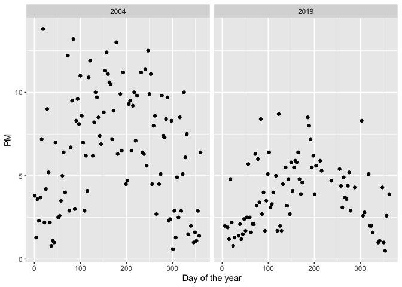

```r
adsub <- filter(ad, STATE_CODE == "6" & COUNTY_CODE == "65" & Site_ID == "60659000") %>%
  select(Date, Year, PM) %>%
  mutate(Date = mdy(Date), yday = yday(Date))

qplot(yday, PM, data = adsub, facets = . ~ Year, xlab = "Day of the year")
```

It seems that PM level went highest in the middle of the year. And it is much lower in 2019 than in 2004.

### Changes in state-wide PM levels

```r
staw <- group_by(ad, Year, STATE_CODE) %>% summarize(PM = mean(PM, na.rm = TRUE)) ;staw
```

```
## # A tibble: 2 × 3
## # Groups:   Year [2]
##    Year STATE_CODE    PM
##   <dbl>      <int> <dbl>
## 1  2004          6 13.1
## 2  2019          6  7.74
```

### Changes in county-wide PM levels

```r
cw <- group_by(ad, Year, COUNTY_CODE) %>% summarize(PM = mean(PM, na.rm = TRUE))
head(cw)
```

```
## # A tibble: 6 × 3
## # Groups:   Year [1]
##    Year COUNTY_CODE    PM
##   <dbl>       <int> <dbl>
## 1  2004           1 11.0
## 2  2004           7 10.1
## 3  2004           9  7.61
## 4  2004          11 10.0
## 5  2004          13 12.8
## 6  2004          15  3.41
```

```r
tail(cw)
```

```
## # A tibble: 6 × 3
## # Groups:   Year [1]
##    Year COUNTY_CODE    PM
##   <dbl>       <int> <dbl>
## 1  2019         101  8.27
## 2  2019         103  5.43
## 3  2019         105  4.91
## 4  2019         107 11.2
## 5  2019         111  6.65
## 6  2019         113  6.85
```

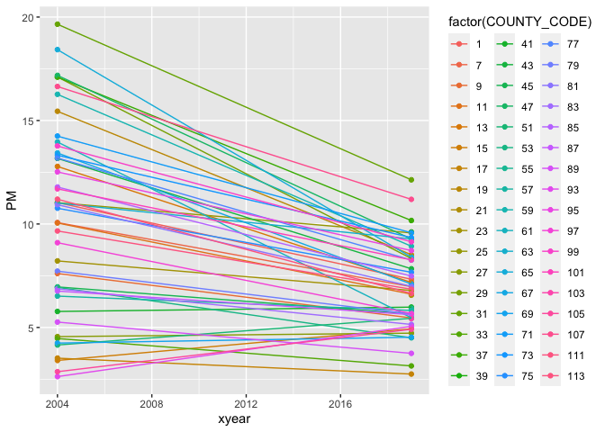

```r
qplot(xyear, PM, data = mutate(cw, xyear = as.numeric(as.character(Year))),
  color = factor(COUNTY_CODE),
  geom = c("point", "line"))
```

```r
sw <- group_by(ad, Year, "Site Name") %>% summarize(PM = mean(PM, na.rm = TRUE))
head(sw)
```

```
## # A tibble: 2 × 3
## # Groups:   Year [2]
##    Year `"Site Name"`    PM
##   <dbl> <chr>         <dbl>
## 1  2004 Site Name     13.1
## 2  2019 Site Name      7.74
```

```r
tail(sw)
```

```
## # A tibble: 2 × 3
## # Groups:   Year [2]
##    Year `"Site Name"`    PM
##   <dbl> <chr>         <dbl>
## 1  2004 Site Name     13.1
## 2  2019 Site Name      7.74
```

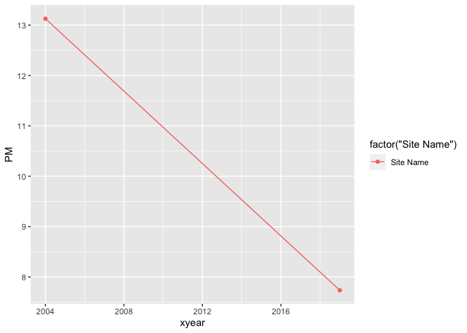

```r
qplot(xyear, PM, data = mutate(sw, xyear = as.numeric(as.character(Year))),
  color = factor("Site Name"),
  geom = c("point", "line"))
```